# Bayesian Regression Closed Form

James Rigby

10/25/2019

Frequentist techniques attempt to maximize the $p(Y|\beta,\sigma)$. This does not rely on any priors. Bayesian technique try to estimate $p(\beta, \sigma|y, X)$ while taking into account prior information. Many representations of the analytic formulas do not illustrate how to take into account priors because it is difficult to do when moving beyond normal distributions and there are memory constraints if relying on a QR factorization with a large number of predictors.

Below I illustrate how to implement bayesian learning regression from scratch. It uses simple OLS estimates of $\hat \beta$ so it is not the most numerically stable in some conditions, but it is a useful to illustrate the analytic solutions (instead of simulation) for bayesian regression and how it can be implemented with informative priors.

Each section has a formulaic representation followed by code written in R.

## Basic Model

$$y = X\beta +\epsilon$$
$$\hat \beta = (X^\top X)^{-1} X^\top y$$

```r
# Defining function to solve for beta
ols_beta<-function(y, X){
solve(crossprod(X, X))%*%crossprod(X,y)
}

# Defining function to solve for sigma squared
ols_sigma_sq<-function(y, X, beta){
  resid<-y-X%*%beta
  k<-ncol(X)

  sum(resid^2)/(nrow(X)-k)
}
```

## Priors

The priors are defined as follows. Interesting the analytic solution for bayesian regression does not require that we solve for $P(\beta, \sigma^2|X)$ as in the typical simulation case. Thus, I do not write functions solve for the joint and marinal probabilities.

$$\beta \sim N(\mu_0, \sigma^2\Lambda_0^{-1})$$
$\lambda_0^{-1}$ is the inverse of the precision matrix. A large $||\Lambda_0||$ would suggest that $\mu_0$ is quite certain.

$\sigma^2$ is the residual variance.

$$\sigma^2 \sim Inv Gamma(a_0, b_0)$$
$$a_0 = \frac{n-k}{2}$$
$$b_0 = .5v_0s^2_0$$

$v_0 =$ prior degrees of freedom for regression ($n-k$) $s^2_0 = $ prior residual variance

Interestingly $b_0$ simplifies to one half the residual sums of squares.

If no information is available $a_0$ and $b_0$ can just be set to really small values so that the distributions peak is closer to 0 (typically incorrect) with a long postive tail.

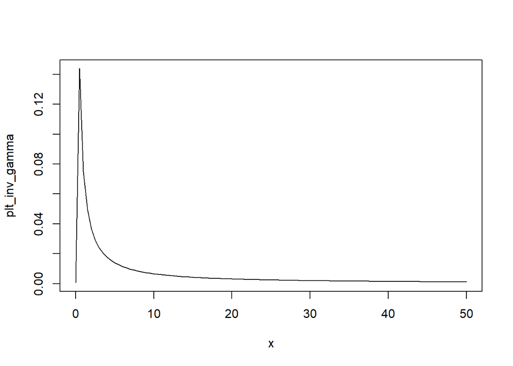

```r
a<-.1
b<-.1

plt_inv_gamma<-function(x){
  invgamma::dinvgamma(x, shape = a, rate = b)
}

plot(plt_inv_gamma, from = .01, to = 50)
```

## Update Rules (Bayesian Learning)

The closed form solution for the update rules are as follows. These are used to define the distributions of the posteriors and sample $\beta$ and $\sigma^2$

$$\mu_n = (X^\top X + \Lambda_0)^{-1} (\Lambda_0\mu_0 + X^\top y)$$
$$\Lambda_n= X^\top X + \Lambda_0$$
$$a_n = a_0 + \frac{n}{2}$$
$$b_n = b_0+.5(y^\top y+\mu_0^\top \Lambda_0 \mu_0 - \mu^T_n \Lambda_n\mu_n)$$

```r
lambda_n<-function(X, lambda_0){
  crossprod(X)+lambda_0
}

mu_n<-function(X, y, lambda_0, m_0){
  l_n<-lambda_n(X, lambda_0)
  solve(l_n)%*%(lambda_0%*%m_0+crossprod(X, y))
  }

a_n<-function(a_0, n){
  a_0+n/2
}

b_n<-function(X, y, b_0, m_0, lambda_0){
  l_n<-lambda_n(X, lambda_0)
  m_n<-mu_n(X, y, lambda_0, m_0)

  b_0 + .5*(crossprod(y)+t(m_0)%*%lambda_0%*%m_0-t(m_n)%*%l_n%*%m_n)
}
```

## Posteriors

$$\beta \sim N(\mu_n, \sigma^2\Lambda_n^{-1})$$

$$\sigma^2 \sim Inv Gamma(a_n, b_n)$$

## Bringing it Together

The below function implements bayesian regression.

```r
bayes_reg<-function(formula, data, lambda_0, m_0, a_0, b_0, draws = 1000){

  # Data Prep ---------------------------------------------------------------
  f<-formula

  x<-model.matrix(f, data)

  y<-data%>%pull(as.character(f[2]))


  # Parameter Extraction ----------------------------------------------------

  # number of parameters
  p<-ncol(x)

  # number of observations
  n<-nrow(x)

  # OLS Parameters ----------------------------------------------------

  # Using ols to solve for beta and sigma_sq
  beta<-ols_beta(y = y, X = x)

  sigma_sq<-ols_sigma_sq(y = y, X = x, beta = beta)

  # Using our update functions defined above
  l_n<-lambda_n(X = x, lambda_0 = lambda_0)
  m_n<-mu_n(X = x, y = y, lambda_0 = lambda_0, m_0 = m_0)
  ap_n<-a_n(a_0 = a_0, n = n)
  bp_n<-b_n(x, y, b_0, m_0, lambda_0)

  # Sampling Distributions ----------------------------------------------------
  # Solving for the posterior vcov of beta
  sigma_post<-sigma_sq*solve(l_n)

  beta_draws<-MASS::mvrnorm(n = draws, mu = m_n, Sigma = sigma_post)
  sig_draws<-invgamma::rinvgamma(n = draws, shape = ap_n, rate = bp_n)

  # Formatting so things look pretty! ----------------------------------------------------

  draws<-as.data.frame(beta_draws)
  draws$sigma_sq<-sig_draws

  model_summary<-draws%>%
    gather(key = "parameter", value = "value")%>%
    group_by(parameter)%>%
    summarise(mean = mean(value),
              median = median(value),
              sd = sd(value))%>%
    gather(key = "Statistic", value = "value", - parameter)%>%
    spread(key = "parameter", value = "value")%>%
    dplyr::select(Statistic, colnames(x), everything())

  params<-list(lambda_n = l_n,
               mu_n = m_n,
               a_n = ap_n,
               b_n = bp_n)

  list(summary = model_summary,
       draws = draws,
       params = params)
}
```

## Illustrating Bayesian Regression

```r
set.seed(1234)
library(tidyverse)
n<-20

# Setting populatoin Parameters
# B0 = 15, B1 = .3, B2 = .6, sd = .74
b0<-15; b1<-.3; b2<-.6; b3 <- .15; rmse<-sqrt(1-sum(c(b1, b2, b3)^2))

# Generating Data Frame
my_dat<-data.frame(x1 = rnorm(n), x2 = rnorm(n), x3 = rnorm(n))%>%
  mutate(y = b0 +b1 * x1+b2 * x2 + b3*x3+ rnorm(n, mean = 0, sd = rmse))


# Low precision
lambda_0<-matrix(c(1, 0, 0, 0,
                   0, 1, 0, 0,
                   0, 0, 1, 0,
                   0, 0, 0, 1), byrow = TRUE, nrow =4)

# noninformative Priors
mu_0<-c(0, 0, 0, 0)


# Fitting Model
m1<-bayes_reg(y~x1+x2+x3, data = my_dat, lambda_0 = lambda_0, m_0 = mu_0, a_0 = .1, b_0 = .1)

# Calculating aboslution deviation from population parameters
sum(abs(as.vector(m1$summary[1, 2:5])-c(b0,b1,b2,b3)))
```

```
## [1] 4.004501
```

```r
# Sampling the population again
my_dat2<-data.frame(x1 = rnorm(n), x2 = rnorm(n), x3 = rnorm(n))%>%
  mutate(y = b0 +b1 * x1+b2 * x2 + b3*x3+ rnorm(n, mean = 0, sd = rmse))
```

```r
# Updating Priors
lambda_0<-m1$params$lambda_n
mu_0<-m1$params$mu_n
a_0<-m1$params$a_n
b_0<-m1$params$b_n

# Fitting model on new sample
m2<-bayes_reg(y~x1+x2+x3, data = my_dat2, lambda_0 = lambda_0, m_0 = mu_0, a_0 = a_0, b_0 = b_0, draws = 1000)

sum(abs(as.vector(m2$summary[1, 2:5])-c(b0,b1,b2,b3)))
```

```
## [1] 0.7588573
```

# Iterative Data Collection Process

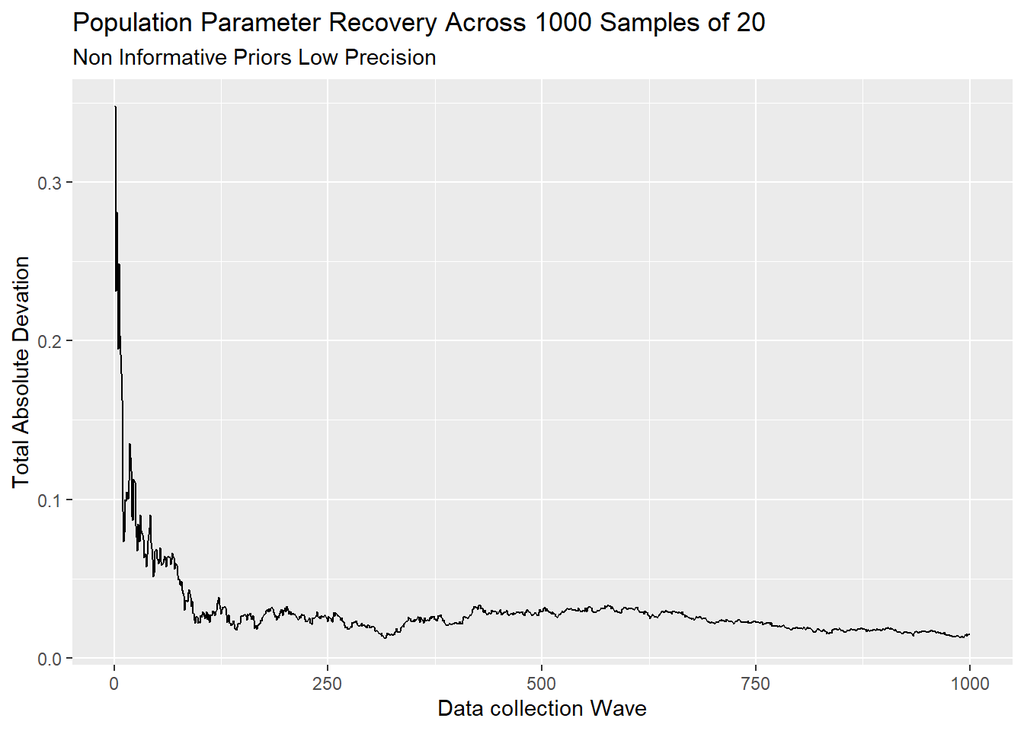

```r
loop<-1000

abs_bias<-numeric(1000)

# Low precision
lambda_0<-matrix(c(.1, 0, 0, 0,
                   0, .1, 0, 0,
                   0, 0, .1, 0,
                   0, 0, 0, .1), byrow = TRUE, nrow =4)

# noninformative Priors
mu_0<-c(0, 0, 0, 0)

a_0<-.1

b_0 = .1


for(i in seq_along(abs_bias)){

  # Sim Data
  my_dat<-data.frame(x1 = rnorm(n), x2 = rnorm(n), x3 = rnorm(n))%>%
  mutate(y = b0 +b1 * x1+b2 * x2 + b3*x3+ rnorm(n, mean = 0, sd = rmse))

  m<-bayes_reg(y~x1+x2+x3, data = my_dat, lambda_0 = lambda_0, m_0 = mu_0, a_0 = a_0, b_0 = b_0, draws = 1000)

abs_bias[i]<-sum(abs(as.vector(m$summary[1, 2:5])-c(b0,b1,b2,b3)))

lambda_0<-m$params$lambda_n
mu_0<-m$params$mu_n
a_0<-m$params$a_n
b_0<-m$params$b_n
}

ggplot(mapping = aes(x = 1:loop, y = abs_bias))+
  geom_line()+
  labs(x = "Data collection Wave",
       title = "Population Parameter Recovery Across 1000 Samples of 20",
       subtitle = "Non Informative Priors Low Precision",
       y =  "Total Absolute Devation")
```

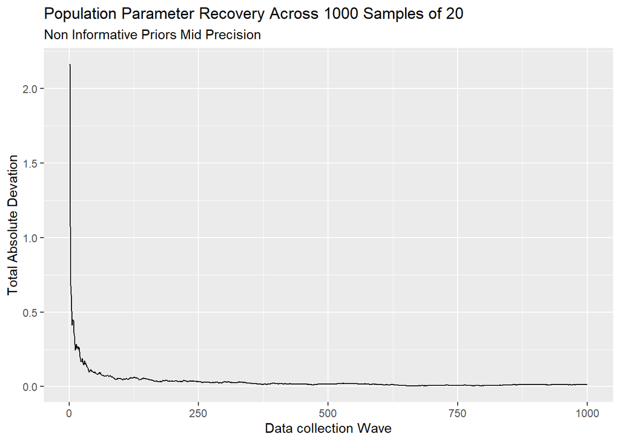

```r
loop<-1000

abs_bias<-numeric(1000)

# Low precision
lambda_0<-matrix(c(1, 0, 0, 0,
                   0, 1, 0, 0,
                   0, 0, 1, 0,
                   0, 0, 0, 1), byrow = TRUE, nrow =4)

# noninformative Priors
mu_0<-c(0, 0, 0, 0)

a_0<-.1

b_0 = .1


for(i in seq_along(abs_bias)){

  # Sim Data
  my_dat<-data.frame(x1 = rnorm(n), x2 = rnorm(n), x3 = rnorm(n))%>%
  mutate(y = b0 +b1 * x1+b2 * x2 + b3*x3+ rnorm(n, mean = 0, sd = rmse))

  m<-bayes_reg(y~x1+x2+x3, data = my_dat, lambda_0 = lambda_0, m_0 = mu_0, a_0 = a_0, b_0 = b_0, draws = 1000)

abs_bias[i]<-sum(abs(as.vector(m$summary[1, 2:5])-c(b0,b1,b2,b3)))

lambda_0<-m$params$lambda_n
mu_0<-m$params$mu_n
a_0<-m$params$a_n
b_0<-m$params$b_n
}

ggplot(mapping = aes(x = 1:loop, y = abs_bias))+
  geom_line()+
  labs(x = "Data collection Wave",
       title = "Population Parameter Recovery Across 1000 Samples of 20",
       subtitle = "Non Informative Priors Mid Precision",
       y =  "Total Absolute Devation")
```

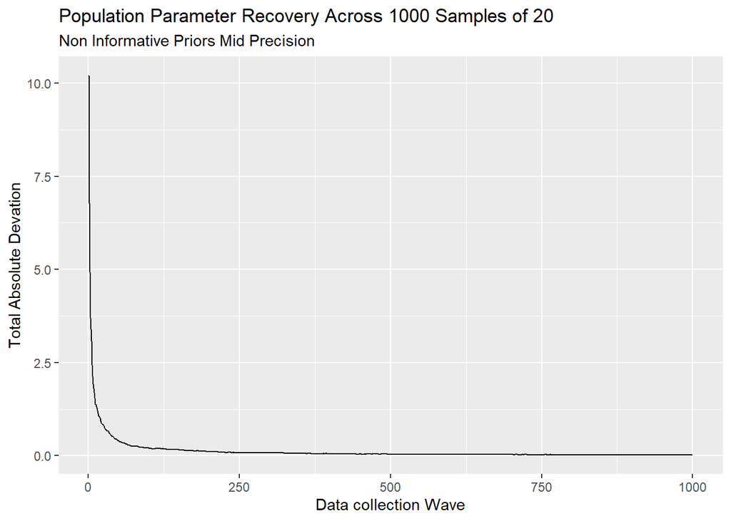

```r
loop<-1000

abs_bias<-numeric(1000)

# Low precision
lambda_0<-matrix(c(20, 0, 0, 0,
                   0, 20, 0, 0,
                   0, 0, 20, 0,
                   0, 0, 0, 20), byrow = TRUE, nrow =4)

# noninformative Priors
mu_0<-c(0, 0, 0, 0)

a_0<-.1

b_0 = .1


for(i in seq_along(abs_bias)){

  # Sim Data
  my_dat<-data.frame(x1 = rnorm(n), x2 = rnorm(n), x3 = rnorm(n))%>%
  mutate(y = b0 +b1 * x1+b2 * x2 + b3*x3+ rnorm(n, mean = 0, sd = rmse))

  m<-bayes_reg(y~x1+x2+x3, data = my_dat, lambda_0 = lambda_0, m_0 = mu_0, a_0 = a_0, b_0 = b_0, draws = 1000)

abs_bias[i]<-sum(abs(as.vector(m$summary[1, 2:5])-c(b0,b1,b2,b3)))

lambda_0<-m$params$lambda_n
mu_0<-m$params$mu_n
a_0<-m$params$a_n
b_0<-m$params$b_n
}

ggplot(mapping = aes(x = 1:loop, y = abs_bias))+
  geom_line()+
  labs(x = "Data collection Wave",
       title = "Population Parameter Recovery Across 1000 Samples of 20",
       subtitle = "Non Informative Priors Mid Precision",
       y =  "Total Absolute Devation")
```

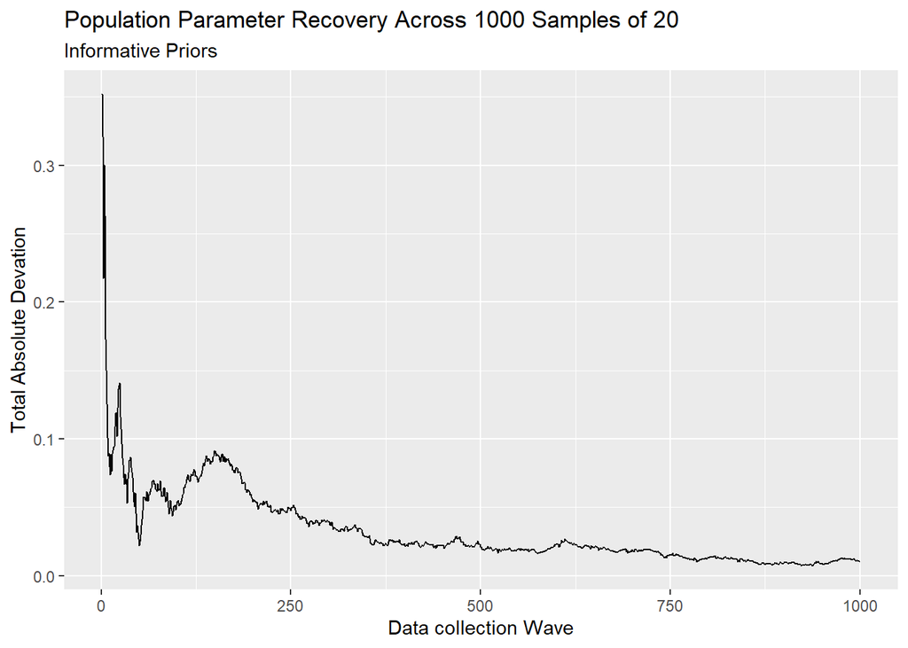

```r
loop<-1000

abs_bias<-numeric(1000)

# B0 = 15, B1 = .3, B2 = .6, sd = .74


# HIGH precision
lambda_0<-matrix(c(20, 0, 0, 0,
                   0, 20, 0, 0,
                   0, 0, 20, 0,
                   0, 0, 0, 20), byrow = TRUE, nrow =4)

# informative Priors
mu_0<-c(15, .13, .6, .15)

a_0<-5

b_0 = .5*(.74)^2*10


for(i in seq_along(abs_bias)){

  # Sim Data
  my_dat<-data.frame(x1 = rnorm(n), x2 = rnorm(n), x3 = rnorm(n))%>%
  mutate(y = b0 +b1 * x1+b2 * x2 + b3*x3+ rnorm(n, mean = 0, sd = rmse))

  m<-bayes_reg(y~x1+x2+x3, data = my_dat, lambda_0 = lambda_0, m_0 = mu_0, a_0 = a_0, b_0 = b_0, draws = 1000)

abs_bias[i]<-sum(abs(as.vector(m$summary[1, 2:5])-c(b0,b1,b2,b3)))

lambda_0<-m$params$lambda_n
mu_0<-m$params$mu_n
a_0<-m$params$a_n
b_0<-m$params$b_n
}

ggplot(mapping = aes(x = 1:loop, y = abs_bias))+
  geom_line()+
  labs(x = "Data collection Wave",
       title = "Population Parameter Recovery Across 1000 Samples of 20",
       subtitle = "Informative Priors",
       y =  "Total Absolute Devation")
```